# Neural_coding_Homework2_UlziiUtas_N

```python
from IPython.display import display, Math, Latex

# Libraries you might need
from matplotlib import pyplot as plt
%matplotlib inline

import numpy as np
import random
import math
from numba import jit, cuda, vectorize
```

```python
# You can use this function for plotting raster plots (spikes), or you can use your own defined function
def raster(event_times_list, color='k', t_max=10.):
    """
    Creates a raster plot
    Parameters
    ----------
    event_times_list : iterable
                       a list of event time iterables
    color : string
            color of vlines
    Returns
    -------
    ax : an axis containing the raster plot
    https://scimusing.wordpress.com/2013/05/06/making-raster-plots-in-python-with-matplotlib/
    """
    plt.figure(figsize=(10,3));
    ax = plt.gca();
    for ith, trial in enumerate(event_times_list):
        plt.vlines(trial, ith + .5, ith + 1.5, color=color);
    plt.ylim(.5, len(event_times_list) + .5);
    ax.set_xlim((0,1));
    return ax
```

### Homework 2

**1. Generation of inhomogeneous Poisson process**. Consider an inhomogeneous Poisson process with instanteneous firing rate $\lambda: [0,1] \to \mathbb{R}^+$ such that $\lambda(t) = \lambda_{max} \frac{t(1-t)}{sec^2}$, where $t$ is measured in seconds, $\lambda$ in Herz [Hz]. In the next 4 points, generate $N = 100$ spike trains for $\lambda_{max} = 100$ Hz. Plot the raster plot and numeric approximation of the rate (by binning the data into 100 bins (bins of length 0.01 sec on interval [0,1] for each spike train) and computing the number of spikes in all spike trains within the bin, devided by $N$ and the bin size).

From, here until the start of 1-a, I wanted to try different approach before trying the 1-a approach which is using uniform distribution for spike generation with Poisson distribution. As expected, the result was same for the two approach.

```python
@jit(nopython = True)
def spike_gen_poiss(t, lam_max):

    spike_train = np.zeros(1000);
    spike_times = np.zeros(100);
    iter = 0;

    for i in range(len(t)-1):
        mean = lam_max * ((t[i+1]**2)/2 - (t[i+1]**3)/3 - (t[i]**2)/2 + (t[i]**3)/3);
        p = mean * np.exp(-mean);
        s = np.random.uniform(0,1,1);

        if s[0] < p:
            spike_train[i] = t[i];

        if (iter + 1) * 0.01 > t[i]:
            if s[0] < p:
                spike_times[iter] += 1;
        else:
            iter += 1;
            if s[0] < p:
                spike_times[iter] += 1;
    return spike_train, spike_times
```

```python
dt = 0.001;
t = np.arange(0, 1.001, dt);
N = 100;
T = 1;
lam_max = 100;
```

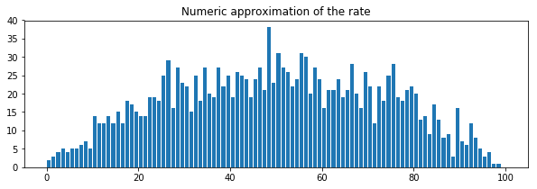

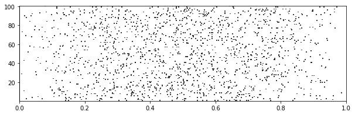

```python
spike_train = [];
spike_times = np.zeros(100);
for i in range(N):
    tmp_spike_train, tmp_spike_times = spike_gen_poiss(t, lam_max);
    spike_train.append(tmp_spike_train);

    spike_times += tmp_spike_times;

spike_times = spike_times;
plt.figure(figsize=(10,3));
plt.bar(np.arange(100)+.5, spike_times);
plt.title('Numeric approximation of the rate');

raster(spike_train);
```

**a) Temporal distribution method:** As in the lecture: first find number of spikes $k$ by drawing from Poisson distribution with parameter $\mu(1) = \int_0^1\lambda(t) dt $, and then draw spike times using a dencity function $\lambda(t)/\mu(1)$. *(2 points)*

1-a exercise is starting here. First, I generated the spike number distribution for 1 second.

```
Spike number with the highest probability:  16
Mean of distribution:  16.666666666666668
```

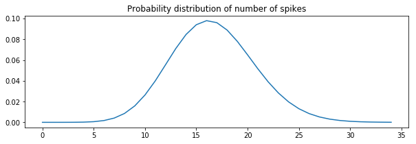

```python
k = np.arange(0,35);
mean = lam_max * (T**2/2 - T**3/3);
number_of_spikes = [];
for i in range(len(k)):
    p = np.power(mean, k[i]) * np.exp(-mean) / math.factorial(k[i]);
    number_of_spikes.append(p);

print('Spike number with the highest probability: ', number_of_spikes.index(max(number_of_spikes)));
print('Mean of distribution: ', mean);

plt.figure(figsize=(10,3));
plt.plot(number_of_spikes);
plt.title('Probability distribution of number of spikes');
```

Because of some calculation there is a very small number left out of 1 probability. So, I added the left out probability to the most right random variable.

```python
sum_of_prob = sum(number_of_spikes[0:34]);
number_of_spikes[len(k)-1] = number_of_spikes[len(k)-1] + (1 - sum(number_of_spikes));
```

I used np.random.choice to draw from the distribution.

```python
number_of_spike_k = np.random.choice(k, p = number_of_spikes);
print('Randomly chosen spike time: ', number_of_spike_k);
```

```
Randomly chosen spike time:  7
```

Here, I generated the univariate density of spike times from 0 to 1 second with 0.001 step.

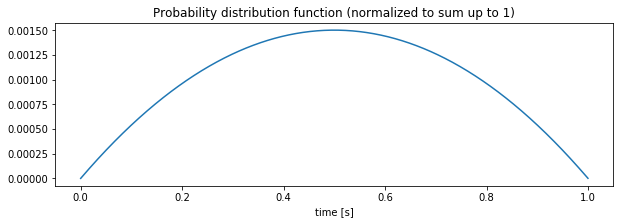

```python
spike_t = np.arange(0, 1.001, 0.001);
spike_times_from_density = [];

for i in range(len(spike_t)-1):
    lam = lam_max * (spike_t[i] - spike_t[i]**2);
    p = lam/mean;
    spike_times_from_density.append(p/1000);
spike_times_from_density.append(1-sum(spike_times_from_density));

plt.figure(figsize=(10,3));
plt.plot(spike_t, spike_times_from_density);
plt.xlabel('time [s]')
plt.title('Probability distribution function (normalized to sum up to 1)');
```

Here, for each spike train i randomly chose k spike from spike number distribution. Then for each spike in k, I randomly choose spike time from univariate density. Also, I have increased the count of spike times of bins.

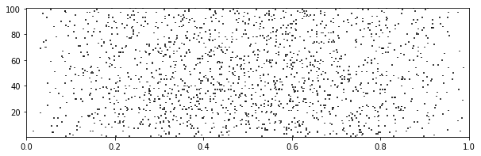

```python
spike_train_for_k_spikes = [];
spike_times = np.zeros(100);
for j in range(N):
    tmp = [];
    number_of_spike_k = np.random.choice(k, p = number_of_spikes);
    for i in range(number_of_spike_k):
        spike_time = np.random.choice(spike_t, p = spike_times_from_density);
        tmp.append(spike_time);
        ind = int(np.floor(spike_time/0.01));
        spike_times[ind] += 1;
    spike_train_for_k_spikes.append(tmp);
raster(spike_train_for_k_spikes);
```

Here, I plotted the numeric approximation of rate. As, shown in raster plot, we can see increase in rate around the middle. Continues line is expected rate for given time

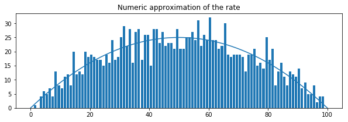

```python
spike_times_from_density_plot = [];

for i in range(len(spike_t)):
    lam = lam_max * (spike_t[i] - spike_t[i]**2);
    p = lam;
    spike_times_from_density_plot.append(p);

spike_times = spike_times;
plt.figure(figsize=(10,3));
plt.bar(np.arange(100)+.5, spike_times);
plt.plot(spike_t * 100, spike_times_from_density_plot);
plt.title('Numeric approximation of the rate');
```

**b) Bernoulli method:** Discretize time into $m$ bins. For each bin $j = 1, \ldots, m$ draw a sample $k_i$ from a Poisson spike count distribution in that bin ( Poisson distribution with the parameter equal to integral of the $\lambda(t)$ over the bin). Generate a single spike in each bin with $k_i > 0$ drawing its time-stamp from uniform distribution within this bin. Generate rasters and estimated rate for $m = 10, \: 100, \: 1000.$ *(2 points)*

```python
@jit(nopython = True)
def spike_count_dist(t2, t1):
    mean_bin = lam_max * ((t2**2)/2 - (t2**3)/3 - (t1**2)/2 + (t1**3)/3);
    k_spikes = np.arange(0, np.ceil(mean_bin)*2+1);
    spike_count_dist_bin = np.zeros(len(k_spikes));

    for l in range(len(k_spikes)):
        fact = 1;
        if k_spikes[l] != 0:
            fact = np.prod(k_spikes[1:l+1]);

        p = np.power(mean_bin, k_spikes[l]) * np.exp(-mean_bin) / fact;
        spike_count_dist_bin[l] = p;

    spike_count_dist_bin[len(k_spikes)-1] = spike_count_dist_bin[len(k_spikes)-1] + (1 - np.sum(spike_count_dist_bin));

    return k_spikes, spike_count_dist_bin, mean_bin
```

```python
@jit(nopython = True)
def time_stamp_uniform_dist(t2, t1, mean_bin, m):

    spike_t_bin = np.arange(t1, t2, T/(m*100));

    spike_times_from_density_bin = np.zeros(len(spike_t_bin));

    for l in range(len(spike_t_bin)-1):
        lam = lam_max * (spike_t_bin[l] - spike_t_bin[l]**2);
        p = lam/mean_bin;
        spike_times_from_density_bin[l] = p/(m*100);

    if np.sum(spike_times_from_density_bin) > 1:
        sub = (np.sum(spike_times_from_density_bin) - 1);

        i = len(spike_times_from_density_bin) - 1;
        while i >= 0:
            if spike_times_from_density_bin[i] > sub:
                spike_times_from_density_bin[i] = spike_times_from_density_bin[i] - sub;
                break;
            i = i -1;
    else:
        spike_times_from_density_bin[len(spike_t_bin)-1] =1-np.sum(spike_times_from_density_bin);

    return spike_t_bin, spike_times_from_density_bin
```

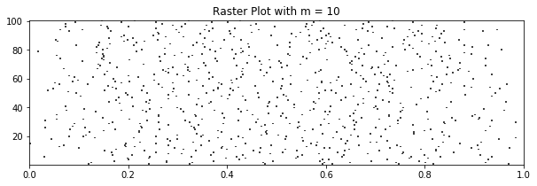

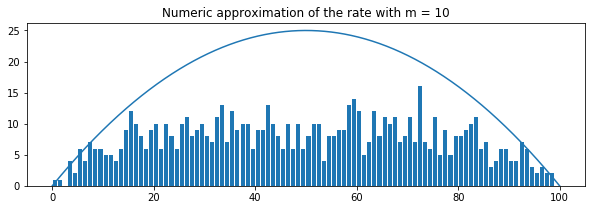

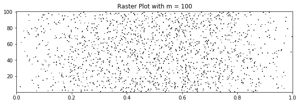

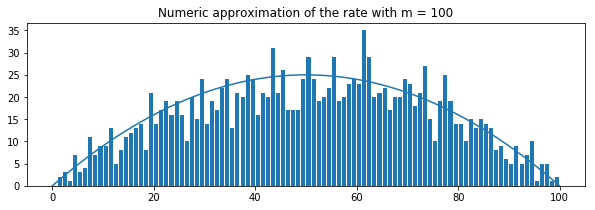

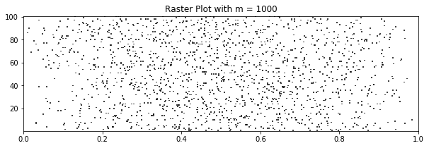

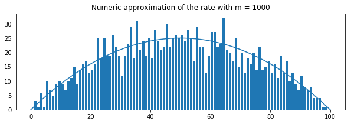

```python
m = [10, 100, 1000]; #
spike_train_bernoulie = [];
spike_times = np.zeros(100);
for i in range(len(m)):
    spike_times = np.zeros(100);
    spike_train_bernoulie = [];
    for l in range(N):
        t_m = np.arange(0, T+T/m[i], T/m[i]);
        poiss_dist_spike_train = [];
        for j in range(len(t_m)-1):
            k_spikes, spike_count_dist_bin, mean_bin = spike_count_dist(t_m[j + 1], t_m[j]);

            chosen_sample_k = np.random.choice(k_spikes, p = spike_count_dist_bin);
            if chosen_sample_k > 0:
                spike_t_bin, spike_times_from_density_bin = time_stamp_uniform_dist(t_m[j + 1], t_m[j], mean_bin, m[i]);
                chosen_spike_time = np.random.choice(spike_t_bin, p = spike_times_from_density_bin);

                poiss_dist_spike_train.append(chosen_spike_time);

                ind = int(np.floor(chosen_spike_time/0.01));
                spike_times[ind] += 1;

        spike_train_bernoulie.append(poiss_dist_spike_train);

    plt.figure(figsize=(10,3));
    ax = plt.gca();
    for ith, trial in enumerate(spike_train_bernoulie):
        plt.vlines(trial, ith + .5, ith + 1.5);
    plt.ylim(.5, len(spike_train_bernoulie) + .5);
    plt.title('Raster Plot with m = {}'.format(m[i]))
    ax.set_xlim((0,1));
    plt.show();

    spike_times = spike_times;
    plt.figure(figsize=(10,3));
    plt.bar(np.arange(100)+.5, spike_times);
    plt.plot(spike_t * 100, spike_times_from_density_plot);
    plt.title('Numeric approximation of the rate with m = {}'.format(m[i]))
    plt.show();
```

As, we can see in all 3 cases we have increased spikes in the middle. When m = 10 we see less but after increasing m from 100 to 1000, I would say we stop seeing increase more than expected rate.

**c) Thinning method:** First generate a spike train from a Poisson process of rate $\lambda_{max}$ and then iterate through all spikes $l = 1, \ldots, k$ and randomly delete them with probability $1 - \lambda(t^\star_l) /\lambda_{max}$, where $t^\star_l$ is a time point of the $l$-th spike (before thinning). *(2 points)*

Homogeneous Poisson spike generation function, for each interval if uniform random variable is less than the probability of generating one spike, I generated a spike. I have used following reference: http://www.cns.nyu.edu/~david/handouts/poisson.pdf

```python
@jit(nopython = True)
def spike_gen_poiss_homo(t, lam_max, dt):

    spike_train = np.zeros(len(t));

    iter = 0;
    mean = lam_max * dt;

    for i in range(len(t)-1):
        p = mean * np.exp(-mean);
        s = np.random.uniform(0,1,1);

        if s[0] < p:
            spike_train[i] = t[i];

    return spike_train
```

I am generating spike train because of 100Hz lambda we see dense spikes.

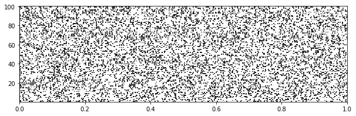

```python
spike_train_thinning = [];
for i in range(N):
    tmp_spike_train = spike_gen_poiss_homo(t, lam_max, 0.001);
    spike_train_thinning.append(tmp_spike_train);

raster(spike_train_thinning);
```

Below, I am deleting with probabilty of $1 - \lambda(t^\star_l) /\lambda_{max}$. As expected, we again can see the increased density of spikes in the middle.

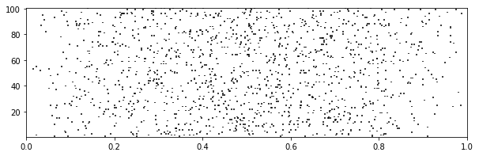

```python
for j in range(N):
    for i in range(len(t)):
        lam_p = 1 - t[i] * (1-t[i]);

        to_delete = np.random.choice([0, 1], p = [1-lam_p, lam_p]);

        if to_delete == 1:
            arr = np.where(spike_train_thinning[j] == t[i]);
            spike_train_thinning[j] = np.delete(spike_train_thinning[j], arr);


raster(spike_train_thinning);
```

**d) Renewal and time rescaling method:** Compute $\mu(t) = \int_0^t \lambda(s) ds$. Generate a spike train for a homogeneous Poisson process with rate $1$ on an interval $[0,\mu(1)]$ (using inter-spike interval distribution as in the previous homework). Resulting spike times we call $s_1^\star, \ldots s_l^\star$. We can then find corresponding pre-images $t_l^\star = \mu^{-1}(s_l^\star) \in [0,1].$

Hint: To find the inverse of a polynomial function at a specific value you can use function np.roots (https://docs.scipy.org/doc/numpy/reference/generated/numpy.roots.html ). You will need a real root within the interval $[0,1]$. You can also use "sympy" library to create symbolic equations and then find the inverse function using those symbolic equations *(2 points)*

```python
mean_renewal = lam_max * ((1**2)/2 - (1**3)/3);
```

Here, I am using rate 1 for spike generation so we can see decreased spike firing.

```
(0, 16.666666666666668)
```

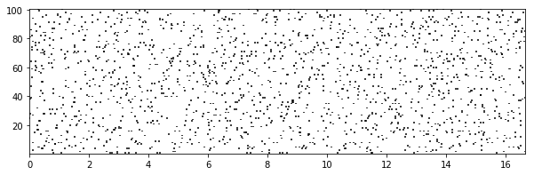

```python
spike_train_renewal = [];
dt_renewal = 0.01;

t_rewewal = np.arange(0, mean_renewal, dt_renewal);

for i in range(N):
    tmp_spike_train = spike_gen_poiss_homo(t_rewewal, 1, dt_renewal);

    arr = np.where(tmp_spike_train == 0);
    tmp_spike_train = np.delete(tmp_spike_train, arr);
    spike_train_renewal.append(tmp_spike_train);

plt.figure(figsize=(10,3))
ax = plt.gca()
for ith, trial in enumerate(spike_train_renewal):
    plt.vlines(trial, ith + .5, ith + 1.5)
plt.ylim(.5, len(spike_train_renewal) + .5)
ax.set_xlim((0,mean_renewal))
```

To get inverse of mean function, I did the following simplification.

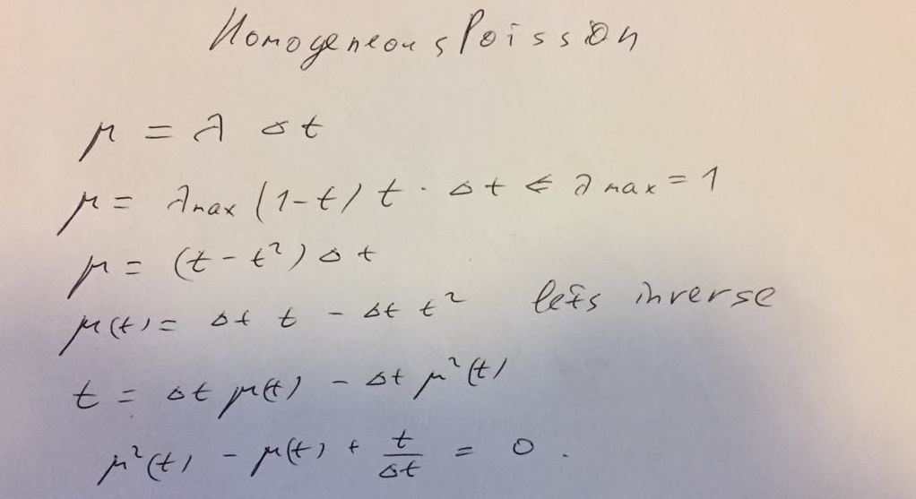

I used np.roots to get the complex answer than got the real root value. The inversed raster plot is same as the original one.

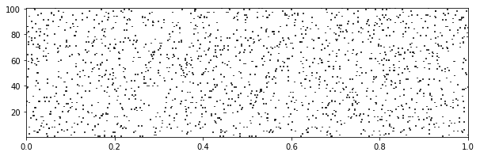

```python
spike_train_renewal_inverse = []
for i in range(N):
    tmp = []
    for j in range(len(spike_train_renewal[i])):
        val = np.roots([1,-1, spike_train_renewal[i][j]/dt_renewal]);
        real_root = (val[0] * val[1] * dt_renewal) / mean_renewal;

        if 0 <= real_root and real_root <= 1:
            tmp.append(real_root);

    spike_train_renewal_inverse.append(tmp);

raster(spike_train_renewal_inverse);
```

**2. Variance of the firing rate a)**. Determine the variance of the firing rate (across the bins) using $b = 10, \: 50, \:100$ bins from spike trains generated by method a) using the law of total variance *(1 point)*

```python
# Generating Spike number distribution from 0 to 35 numbers.
k = np.arange(0,35);
lam_max = 100;
mean = lam_max * (T**2/2 - T**3/3);
number_of_spikes = [];

for i in range(len(k)):
    p = np.power(mean, k[i]) * np.exp(-mean) / math.factorial(k[i]);
    number_of_spikes.append(p);
sum_of_prob = sum(number_of_spikes[0:34]);
number_of_spikes[len(k)-1] = number_of_spikes[len(k)-1] + (1 - sum(number_of_spikes));

# Generating Spike Times density from 0 to 1 with 0.001 step.
spike_t_2a = np.arange(0, 1.001, 0.001);
spike_times_from_density_2a = [];

for i in range(len(spike_t_2a)-1):
    lam = lam_max * (spike_t_2a[i] - spike_t_2a[i]**2);
    p = lam/mean;
    spike_times_from_density_2a.append(p/1000);
spike_times_from_density_2a.append(1-sum(spike_times_from_density_2a));
```

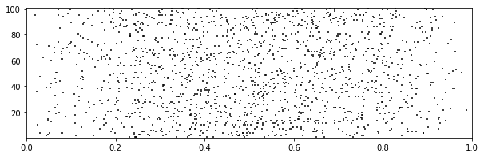

```python
spike_train_for_k_spikes_2a = []
spike_times_bin10 = np.zeros([100,10]);
spike_times_bin50 = np.zeros([100,50]);
spike_times_bin100 = np.zeros([100,100]);

times_bin10 = np.arange(0,1, 1/10);
times_bin50 = np.arange(0,1, 1/50);
times_bin100 = np.arange(0,1, 1/100);

for j in range(N):
    tmp = [];

#     Generating number of spikes for each train
    number_of_spike_k = np.random.choice(k, p = number_of_spikes);

    for i in range(number_of_spike_k):

#     Generating spike time for each spike
        val = np.random.choice(spike_t_2a, p = spike_times_from_density_2a);

        tmp.append(val);

        ind = int(np.floor(val/0.01));
        spike_times_bin100[j][ind] += 1;

        ind = int(np.floor(val/0.02));
        spike_times_bin50[j][ind] += 1;

        ind = int(np.floor(val/0.1));
        spike_times_bin10[j][ind] += 1;

    spike_train_for_k_spikes_2a.append(tmp);

raster(spike_train_for_k_spikes_2a);
```

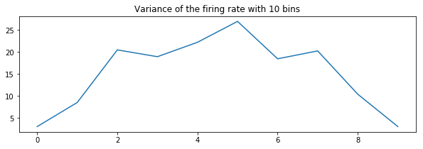

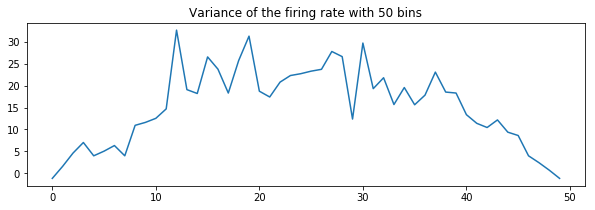

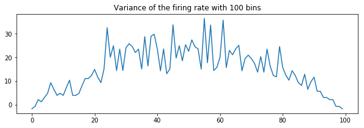

```python
var_bin10 = np.zeros(10);
var_bin50 = np.zeros(50);
var_bin100 = np.zeros(100);
for i in range(10):
    var_bin10[i] = np.var(spike_times_bin10[:,i])/np.power(0.1,2) - np.sum(spike_times_bin10/1000)/0.1;
for i in range(50):
    var_bin50[i] = np.var(spike_times_bin50[:,i])/np.power(0.02,2) - np.sum(spike_times_bin50/1000) / 0.02;
for i in range(100):
    var_bin100[i] = np.var(spike_times_bin100[:,i])/np.power(0.01,2) - np.sum(spike_times_bin100/1000) / 0.01;

plt.figure(figsize=(10,3));
plt.plot(var_bin10/10);
plt.title('Variance of the firing rate with 10 bins');
plt.show();
plt.figure(figsize=(10,3));
plt.plot(var_bin50/50);
plt.title('Variance of the firing rate with 50 bins');
plt.show();
plt.figure(figsize=(10,3));
plt.plot(var_bin100/100);
plt.title('Variance of the firing rate with 100 bins');
plt.show();
```

In all three cases, we see increased variance of firing rate in the middle of time.

**2. Variance of the firing rate b)**. Compare results form 2.a) with analytical variance of the rate. To compute the analytical variance use the true formula for the time-dependent rate $\lambda(t) = \lambda_{max} \frac{t(1-t)}{sec^2}$ and treat it as a random variable for the time $t$ uniformly distributed in $[0,1]$. *(1 point)*

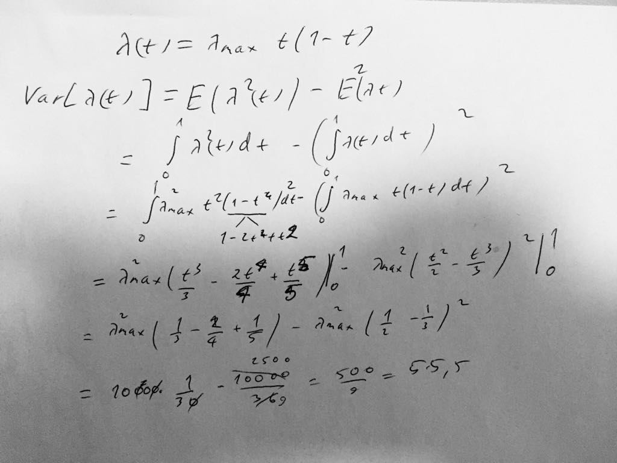